# Empirical Replication: Ethanol Plant Entry and Local Corn Prices

Replication of Jung, Sesmero, and Siebert (American Journal of Agricultural Economics 2026)

Kexi Huang

September 5, 2026

# 1 Introduction and Empirical Identification

This project replicates the primary empirical findings of Jung, Sesmero, and Siebert (2026), *“Spatial Price Competition in Agricultural Markets: The Case of Ethanol Plant Entry”*, published in the *American Journal of Agricultural Economics*.

The authors investigate how localized demand shocks generated by ethanol biorefinery entry affect regional corn bid prices across Midwestern grain elevators. Because grain transportation is costly, spatial price competition creates heterogeneous price premiums that decay over geographic space and scale with facility processing capacity relative to local agricultural supply.

The primary identification strategy relies on a fully saturated Two-Way Fixed Effects (TWFE) Difference-in-Differences specification:
$$\text{CornPrice}_{eit} = \alpha_0 +
\gamma_e + \theta_t + \delta_0 (\text{Entry}_{eit} \times \text{Post}_t)
+ \delta_1 (\text{Entry}_{eit} \times \text{Post}_t \times
\widetilde{\text{Ratio}}_{eit}) + \delta_2 (\text{Entry}_{eit} \times
\text{Post}_t \times \text{Dist}_{ei}) + \dots + \eta X_{eit} +
\varepsilon_{eit}$$

# 2 Data Preparation and Spatial Metrics

The primary dataset (`DID_Submission.xlsx`) contains a balanced two-period panel of $N = 536$ observations across $G = 268$ grain elevators observed across pre-treatment (2004–2006 average) and post-treatment (2013–2014 average) windows.

```r
library(readxl)
library(dplyr)
library(tidyr)
library(fixest)

# Prevent C++ OpenMP thread deadlocks in fixest on Intel Macs
setFixest_nthreads(1)

# Import and clean the main dataset
df <- read_excel("../data/DID_Submission.xlsx", sheet = "Data")

mean_ratio <- mean(df$RATIONEARTOT[df$YEAR2013 == 1], na.rm = TRUE)

df <- df %>%
  rename(
    CPRICE2014SRCELEV = `CPRICE$2014SRCELEV`,
    TOTLSTOCKDEMANDMBY = `TOTLSTOCKDEMAND (MBY)`
  ) %>%
  mutate(
    RATIOSQNEARTREAT = YEAR2013TREAT * RATIONEARTOT * RATIONEARTOT,
    DISTNEARTREAT = YEAR2013TREAT * NEAR_DIST_MILES,
    DISTSQNEARTREAT = YEAR2013TREAT * NEAR_DIST_MILES * NEAR_DIST_MILES,
    MEANRATIONEARTOT = ifelse(YEAR2013 == 1, mean_ratio, NA_real_),
    DMRATIONEARTOT = RATIONEARTOT - MEANRATIONEARTOT,
    DMRATIONEARTREAT = YEAR2013TREAT * DMRATIONEARTOT,
    DMRATIOSQNEARTREAT = YEAR2013TREAT * DMRATIONEARTOT * DMRATIONEARTOT,
    DMRATIOTOTNEARDISTTREAT = YEAR2013TREAT * DMRATIONEARTOT * NEAR_DIST_MILES,
    DMRATIOTOTNEARDISTSQTREAT = YEAR2013TREAT * DMRATIONEARTOT * NEAR_DIST_MILES * NEAR_DIST_MILES
  ) %>%
  mutate(
    across(
      c(DMRATIONEARTREAT, DMRATIOSQNEARTREAT, DMRATIOTOTNEARDISTTREAT, DMRATIOTOTNEARDISTSQTREAT),
      ~ replace_na(.x, 0)
    )
  )
```

# 3 Main Specifications: Local Corn Price Impacts (Table 3)

We estimate a nested sequence of specifications that progressively incorporates treatment intensity and spatial attenuation. Standard errors are clustered at the grain elevator level (`ID`) to correct for arbitrary serial correlation.

```r
# Baseline DiD with Elevator Fixed Effects (Model 2)
m2 <- feols(CPRICE2014SRCELEV ~ YEAR2013 + YEAR2013TREAT + TOTLSTOCKDEMANDMBY | ID,
            cluster = ~ID, data = df)

# Model 6 (De-meaned Ratio + Distance Interaction)
m6 <- feols(CPRICE2014SRCELEV ~ YEAR2013 + YEAR2013TREAT + DMRATIONEARTREAT +
              DISTNEARTREAT + TOTLSTOCKDEMANDMBY | ID, cluster = ~ID, data = df)

# Model 11 (Fully Saturated Model - Authors' Preferred Specification)
m11 <- feols(CPRICE2014SRCELEV ~ YEAR2013 + YEAR2013TREAT + DMRATIONEARTREAT +
               DMRATIOSQNEARTREAT + DMRATIOTOTNEARDISTTREAT + DMRATIOTOTNEARDISTSQTREAT +
               DISTNEARTREAT + DISTSQNEARTREAT + TOTLSTOCKDEMANDMBY | ID,
             cluster = ~ID, data = df)
```

## 3.1 Regression Results Output

The table below reports the progressive estimates. Model 11 demonstrates that ethanol plant entry generates a local price premium of **+$0.1567 per bushel** ($p < 0.01$) at the plant gate, scaling positively with relative plant size (`DMRATIONEARTREAT` $= +0.0990$) and attenuating by** $0.0067 per mile** (`DISTNEARTREAT` $= -0.0067$).

```r
# Generate the table as a clean data frame
table_data <- etable(m2, m6, m11,
                     headers = c("Baseline DiD (M2)", "Spatial Decay (M6)", "Fully Saturated (M11)"))

knitr::kable(table_data, caption = "Table 3: Impact of Ethanol Plant Entry on Local Corn Prices (TWFE Specifications)")
```

Table 3: Impact of Ethanol Plant Entry on Local Corn Prices (TWFE Specifications)

|  | m2 | m6 | m11 |
| --- | --- | --- | --- |
|  | Baseline DiD (M2) | Spatial Decay (M6) | Fully Saturated (M11) |
| Dependent Var.: | CPRICE2014SRCELEV | CPRICE2014SRCELEV | CPRICE2014SRCELEV |
| YEAR2013 | 2.418*** (0.0244) | 2.417*** (0.0244) | 2.418*** (0.0245) |
| YEAR2013TREAT | 0.0807** (0.0296) | 0.1187** (0.0423) | 0.1567** (0.0537) |
| TOTLSTOCKDEMANDMBY | 0.0059 (0.0078) | 0.0089 (0.0071) | 0.0062 (0.0065) |
| DMRATIONEARTREAT |  | -0.0256 (0.0163) | 0.0990* (0.0468) |
| DISTNEARTREAT |  | -0.0016 (0.0012) | -0.0067* (0.0031) |
| DMRATIOSQNEARTREAT |  |  | 0.0348 (0.0229) |
| DMRATIOTOTNEARDISTTREAT |  |  | -0.0068* (0.0030) |
| DMRATIOTOTNEARDISTSQTREAT |  |  | 7.56e-5. (4.19e-5) |
| DISTSQNEARTREAT |  |  | 8.06e-5. (4.69e-5) |
| Fixed-Effects: | —————– | —————– | —————— |
| ID | Yes | Yes | Yes |
| _________________________ | _________________ | _________________ | __________________ |
| S.E.: Clustered | by: ID | by: ID | by: ID |
| Observations | 536 | 536 | 536 |
| R2 | 0.99144 | 0.99157 | 0.99179 |
| Within R2 | 0.99133 | 0.99146 | 0.99168 |

# 4 Dynamic Price Adjustments & Panel Extensions

To validate the parallel trends assumption and trace out dynamic price adjustments over time, we estimate the Callaway and Sant’Anna (2021) doubly robust staggered DiD estimator across the 11-year panel (`StaggeredDID_Submission.xlsx`). We also estimate standard annual panel regressions (Table C4) to evaluate why transitional construction lags attenuate spatial distance gradients in annual data.

## 4.1 Staggered DiD Event Study (Table A1)

```r
library(did)
library(ggplot2)

# Import the staggered panel dataset
df_panel <- read_excel("../data/StaggeredDID_Submission.xlsx", sheet = "Data")

df_panel <- df_panel %>%
  rename(
    CPRICE2014SRCELEV = `CPRICE$2014SRCELEV`
  ) %>%
  mutate(
    FIRST_TREAT = replace_na(FIRST_TREAT, 0),
    ID = as.integer(ID),
    YEAR = as.integer(YEAR),
    FIRST_TREAT = as.integer(FIRST_TREAT)
  )

# Step A: Estimate group-time average treatment effects ATT(g, t)
cs_att <- att_gt(
  yname = "CPRICE2014SRCELEV",
  tname = "YEAR",
  idname = "ID",
  gname = "FIRST_TREAT",
  data = df_panel,
  control_group = "nevertreated",
  est_method = "dr",
  clustervars = "ID",
  print_details = FALSE
)

# Step B: Aggregate ATT(g, t) into an event study
cs_event <- aggte(cs_att, type = "dynamic", na.rm = TRUE)

# Step C: Extract Table A1 coefficients and Standard Pointwise 95% Confidence Intervals
table_a1 <- data.frame(
  Event_Time = cs_event$egt,
  Estimate   = round(cs_event$att.egt, 4),
  Std_Error  = round(cs_event$se.egt, 4),
  Lower_95CI = round(cs_event$att.egt - 1.96 * cs_event$se.egt, 4),
  Upper_95CI = round(cs_event$att.egt + 1.96 * cs_event$se.egt, 4)
)

knitr::kable(table_a1, caption = "Table A1: Dynamic Treatment Effects (Callaway & Sant'Anna 2021)")
```

Table A1: Dynamic Treatment Effects (Callaway & Sant’Anna 2021)

| Event_Time | Estimate | Std_Error | Lower_95CI | Upper_95CI |
| --- | --- | --- | --- | --- |
| -7 | -0.2512 | 0.0862 | -0.4200 | -0.0823 |
| -6 | 0.0504 | 0.0398 | -0.0276 | 0.1283 |
| -5 | -0.0370 | 0.0478 | -0.1308 | 0.0568 |
| -4 | 0.0677 | 0.0294 | 0.0101 | 0.1253 |
| -3 | -0.0364 | 0.0277 | -0.0907 | 0.0180 |
| -2 | 0.0066 | 0.0212 | -0.0350 | 0.0481 |
| -1 | -0.0218 | 0.0165 | -0.0542 | 0.0106 |
| 0 | 0.0280 | 0.0218 | -0.0146 | 0.0707 |
| 1 | -0.0336 | 0.0250 | -0.0825 | 0.0154 |
| 2 | 0.1100 | 0.0216 | 0.0677 | 0.1523 |
| 3 | 0.0716 | 0.0272 | 0.0182 | 0.1249 |
| 4 | 0.0797 | 0.0330 | 0.0150 | 0.1445 |
| 5 | 0.0770 | 0.0346 | 0.0092 | 0.1447 |
| 6 | 0.1504 | 0.0462 | 0.0598 | 0.2410 |
| 7 | 0.0897 | 0.0483 | -0.0051 | 0.1844 |

## 4.2 Visualizing the Dynamic Price Gradient (Figure A1)

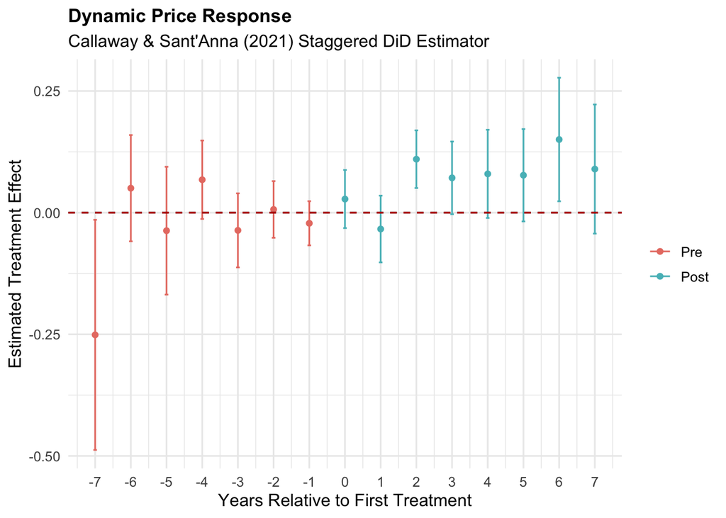

Figure A1: Dynamic Price Response to First Ethanol Plant Entry

```r
p_event <- ggdid(cs_event) +
  theme_minimal(base_size = 12) +
  geom_hline(yintercept = 0, linetype = "dashed", color = "red", alpha = 0.7) +
  labs(
    title = "Dynamic Price Response",
    subtitle = "Callaway & Sant'Anna (2021) Staggered DiD Estimator",
    x = "Years Relative to First Treatment",
    y = "Estimated Treatment Effect"
  ) +
  theme(plot.title = element_text(face = "bold", size = 13))

print(p_event)
```

```r
# Save high-resolution figure to output directory
if (!dir.exists("../output")) dir.create("../output")
ggsave("../output/Figure_A1_Event_Study.png", plot = p_event, width = 8, height = 5, dpi = 300)
```

## 4.3 Annual Panel Regressions (Table C4)

```r
# Full Elevator-Year Panel Regressions (Appendix Table C4)
panel_m1 <- feols(CPRICE2014SRCELEV ~ NEAR_DIST_MILES + USAGEEPLANTTOT_NEAR + TOTLSTOCKDEMAND,
                  cluster = ~ID, data = df_panel)
panel_m2 <- feols(CPRICE2014SRCELEV ~ NEAR_DIST_MILES + USAGEEPLANTTOT_NEAR + TOTLSTOCKDEMAND | ID,
                  cluster = ~ID, data = df_panel)
panel_m3 <- feols(CPRICE2014SRCELEV ~ NEAR_DIST_MILES + USAGEEPLANTTOT_NEAR + TOTLSTOCKDEMAND | YEAR,
                  cluster = ~ID, data = df_panel)
panel_m4 <- feols(CPRICE2014SRCELEV ~ NEAR_DIST_MILES + USAGEEPLANTTOT_NEAR + TOTLSTOCKDEMAND | ID + YEAR,
                  cluster = ~ID, data = df_panel)

table_c4_data <- etable(panel_m1, panel_m2, panel_m3, panel_m4,
                        headers = c("Pooled OLS", "Elevator FE", "Year FE", "Both FE"))

knitr::kable(table_c4_data, caption = "Table C4: Annual Panel Regressions (2004–2014)")
```

Table C4: Annual Panel Regressions (2004–2014)

|  | panel_m1 | panel_m2 | panel_m3 | panel_m4 |
| --- | --- | --- | --- | --- |
|  | Pooled OLS | Elevator FE | Year FE | Both FE |
| Dependent Var.: | CPRICE2014SRCELEV | CPRICE2014SRCELEV | CPRICE2014SRCELEV | CPRICE2014SRCELEV |
| Constant | 5.114*** (0.0672) |  |  |  |
| NEAR_DIST_MILES | -0.0086*** (0.0005) | -0.0130*** (0.0005) | 0.0005*** (9.12e-5) | -3.32e-6 (0.0001) |
| USAGEEPLANTTOT_NEAR | 0.2014*** (0.0296) | 0.3742*** (0.0400) | 0.0076. (0.0045) | 0.0054 (0.0050) |
| TOTLSTOCKDEMAND | -1.2e-8 (1.16e-8) | 3.71e-7*** (4.22e-8) | -8.93e-10 (2.26e-9) | 1.23e-8. (6.7e-9) |
| Fixed-Effects: | ——————- | ——————– | ——————- | —————– |
| ID | No | Yes | No | Yes |
| YEAR | No | No | Yes | Yes |
| ___________________ | ___________________ | ____________________ | ___________________ | _________________ |
| S.E.: Clustered | by: ID | by: ID | by: ID | by: ID |
| Observations | 2,948 | 2,948 | 2,948 | 2,948 |
| R2 | 0.27363 | 0.48255 | 0.98222 | 0.98575 |
| Within R2 | – | 0.48061 | 0.01428 | 0.00248 |

# 5 Alternative Models & Spatial Inference (Appendix C)

To examine the sensitivity of the baseline TWFE estimates, we re-estimate the models using pooled OLS, traditional Difference-in-Differences, alternative spatial clustering, and sample trimming.

## 5.1 Pooled OLS and Regular Difference-in-Differences (Tables C2 & C3)

```r
# Data Preparation for Posey Exclusion
df_no_posey <- df %>%
  dplyr::filter(`county name` != "Posey")

# Table C2: Regular OLS (No Fixed Effects)
m_ols <- feols(CPRICE2014SRCELEV ~ NEAR_DIST_MILES + DMRATIONEARTREAT + TOTLSTOCKDEMANDMBY,
               cluster = ~ID, data = df)

m_ols_no_posey <- feols(CPRICE2014SRCELEV ~ NEAR_DIST_MILES + DMRATIONEARTREAT + TOTLSTOCKDEMANDMBY,
                        cluster = ~ID, data = df_no_posey)

# Table C3: Regular Difference-in-Differences
m_did <- feols(CPRICE2014SRCELEV ~ YEAR2013 + TREATMENT + YEAR2013TREAT + TOTLSTOCKDEMANDMBY,
               cluster = ~ID, data = df)

m_did_no_posey <- feols(CPRICE2014SRCELEV ~ YEAR2013 + TREATMENT + YEAR2013TREAT + TOTLSTOCKDEMANDMBY,
                        cluster = ~ID, data = df_no_posey)

table_c2_c3 <- etable(m_ols, m_ols_no_posey, m_did, m_did_no_posey,
                      headers = c("OLS (Full)", "OLS (No Posey)", "Reg DiD (Full)", "Reg DiD (No Posey)"))

knitr::kable(table_c2_c3, caption = "Tables C2 & C3: Alternative Baseline Specifications")
```

Tables C2 & C3: Alternative Baseline Specifications

|  | m_ols | m_ols_no_posey | m_did | m_did_no_posey |
| --- | --- | --- | --- | --- |
|  | OLS (Full) | OLS (No Posey) | Reg DiD (Full) | Reg DiD (No Posey) |
| Dependent Var.: | CPRICE2014SRCELEV | CPRICE2014SRCELEV | CPRICE2014SRCELEV | CPRICE2014SRCELEV |
| Constant | 4.824*** (0.0506) | 4.840*** (0.0530) | 2.726*** (0.0177) | 2.724*** (0.0177) |
| NEAR_DIST_MILES | -0.0090*** (0.0004) | -0.0094*** (0.0004) |  |  |
| DMRATIONEARTREAT | -0.0988. (0.0543) | -0.1014. (0.0538) |  |  |
| TOTLSTOCKDEMANDMBY | -0.0120 (0.0115) | -0.0089 (0.0118) | -0.0051 (0.0038) | -0.0040 (0.0037) |
| YEAR2013 |  |  | 2.421*** (0.0244) | 2.421*** (0.0244) |
| TREATMENT |  |  | -0.0446* (0.0190) | -0.0527** (0.0187) |
| YEAR2013TREAT |  |  | 0.0793** (0.0297) | 0.0823** (0.0298) |
| __________________ | ___________________ | ___________________ | _________________ | __________________ |
| S.E.: Clustered | by: ID | by: ID | by: ID | by: ID |
| Observations | 536 | 528 | 536 | 528 |
| R2 | 0.44238 | 0.45222 | 0.97840 | 0.97905 |
| Adj. R2 | 0.43924 | 0.44909 | 0.97823 | 0.97889 |

> **Methodological Note on Table C2 Regressors:**  
> The authors’ original specification for the cross-sectional OLS model pairs a raw geographic distance variable (`NEAR_DIST_MILES`) with a post-treatment interacted capacity ratio (`DMRATIONEARTREAT`). While mixing time-invariant variables with post-treatment interactions is an unconventional choice for baseline OLS, we strictly replicate this exact formula to ensure our coefficients perfectly match their published results.

## 5.2 Alternative Spatial Inference and Conley Standard Errors (Table C5)

We re-estimate Model 11 under county-level clustering (`fip`) and Conley spatial HAC standard errors with distance cutoffs at 80 and 160 miles.

```r
# 1. Clustered at the County level (fip)
m11_county <- summary(m11, cluster = ~fip)

# 2. Conley Spatial Standard Errors at 80 miles
m11_conley80 <- summary(m11, vcov = vcov_conley(lat = "latitude", lon = "longitude", cutoff = "80mi"))

# 3. Conley Spatial Standard Errors at 160 miles
m11_conley160 <- summary(m11, vcov = vcov_conley(lat = "latitude", lon = "longitude", cutoff = "160mi"))

table_c5 <- etable(m11, m11_county, m11_conley80, m11_conley160,
                   headers = c("Elevator Cluster", "County Cluster", "Conley (80 mi)", "Conley (160 mi)"))

knitr::kable(table_c5, caption = "Table C5: Alternative Standard Errors and Spatial Autocorrelation")
```

Table C5: Alternative Standard Errors and Spatial Autocorrelation

|  | m11 | m11_county | m11_conley80 | m11_conley160 |
| --- | --- | --- | --- | --- |
|  | Elevator Cluster | County Cluster | Conley (80 mi) | Conley (160 mi) |
| Dependent Var.: | CPRICE2014SRCELEV | CPRICE2014SRCELEV | CPRICE2014SRCELEV | CPRICE2014SRCELEV |
| YEAR2013 | 2.418*** (0.0245) | 2.418*** (0.0331) | 2.418*** (0.0300) | 2.418*** (0.0176) |
| YEAR2013TREAT | 0.1567** (0.0537) | 0.1567* (0.0724) | 0.1567* (0.0661) | 0.1567* (0.0696) |
| DMRATIONEARTREAT | 0.0990* (0.0468) | 0.0990 (0.0704) | 0.0990 (0.1096) | 0.0990. (0.0597) |
| DMRATIOSQNEARTREAT | 0.0348 (0.0229) | 0.0348 (0.0308) | 0.0348 (0.0303) | 0.0348 (0.0454) |
| DMRATIOTOTNEARDISTTREAT | -0.0068* (0.0030) | -0.0068 (0.0045) | -0.0068 (0.0054) | -0.0068* (0.0030) |
| DMRATIOTOTNEARDISTSQTREAT | 7.56e-5. (4.19e-5) | 7.56e-5 (5.75e-5) | 7.56e-5 (7.43e-5) | 7.56e-5 (5.11e-5) |
| DISTNEARTREAT | -0.0067* (0.0031) | -0.0067. (0.0040) | -0.0067 (0.0050) | -0.0067 (0.0056) |
| DISTSQNEARTREAT | 8.06e-5. (4.69e-5) | 8.06e-5 (5.82e-5) | 8.06e-5 (9.4e-5) | 8.06e-5 (10e-5) |
| TOTLSTOCKDEMANDMBY | 0.0062 (0.0065) | 0.0062 (0.0080) | 0.0062 (0.0166) | 0.0062. (0.0032) |
| Fixed-Effects: | —————— | —————– | —————– | —————– |
| ID | Yes | Yes | Yes | Yes |
| _________________________ | __________________ | _________________ | _________________ | _________________ |
| S.E. type | by: ID | by: fip | Conley (80mi) | Conley (160mi) |
| Observations | 536 | 536 | 536 | 536 |
| R2 | 0.99179 | 0.99179 | 0.99179 | 0.99179 |
| Within R2 | 0.99168 | 0.99168 | 0.99168 | 0.99168 |

## 5.3 Outlier Sensitivity: Posey County Exclusion (Table C6)

Posey County is identified by the authors as a geographic outlier with extreme capacity-to-supply values. Dropping Posey County (8 observations across 4 elevators) leaves $N = 528$.

```r
m11_no_posey <- feols(CPRICE2014SRCELEV ~ YEAR2013 + YEAR2013TREAT + DMRATIONEARTREAT +
                        DMRATIOSQNEARTREAT + DMRATIOTOTNEARDISTTREAT + DMRATIOTOTNEARDISTSQTREAT +
                        DISTNEARTREAT + DISTSQNEARTREAT + TOTLSTOCKDEMANDMBY | ID,
                      cluster = ~ID, data = df_no_posey)

table_c6 <- etable(m11, m11_no_posey,
                   headers = c("Original (w/ Posey)", "Excluded (w/o Posey)"))

knitr::kable(table_c6, caption = "Table C6: Saturated Fixed Effects Model Excluding Posey County")
```

Table C6: Saturated Fixed Effects Model Excluding Posey County

|  | m11 | m11_no_posey |
| --- | --- | --- |
|  | Original (w/ Posey) | Excluded (w/o Posey) |
| Dependent Var.: | CPRICE2014SRCELEV | CPRICE2014SRCELEV |
| YEAR2013 | 2.418*** (0.0245) | 2.418*** (0.0245) |
| YEAR2013TREAT | 0.1567** (0.0537) | 0.2045*** (0.0519) |
| DMRATIONEARTREAT | 0.0990* (0.0468) | 0.1296** (0.0417) |
| DMRATIOSQNEARTREAT | 0.0348 (0.0229) | 0.0325 (0.0228) |
| DMRATIOTOTNEARDISTTREAT | -0.0068* (0.0030) | -0.0087** (0.0029) |
| DMRATIOTOTNEARDISTSQTREAT | 7.56e-5. (4.19e-5) | 0.0001* (4.14e-5) |
| DISTNEARTREAT | -0.0067* (0.0031) | -0.0097*** (0.0029) |
| DISTSQNEARTREAT | 8.06e-5. (4.69e-5) | 0.0001** (4.55e-5) |
| TOTLSTOCKDEMANDMBY | 0.0062 (0.0065) | 0.0055 (0.0064) |
| Fixed-Effects: | —————— | ——————- |
| ID | Yes | Yes |
| _________________________ | __________________ | ___________________ |
| S.E.: Clustered | by: ID | by: ID |
| Observations | 536 | 528 |
| R2 | 0.99179 | 0.99193 |
| Within R2 | 0.99168 | 0.99183 |

Excluding Posey County increases the estimated plant-gate price premium from $+0.1567$ to **+$0.2045 per bushel** ($p < 0.01$).

# 6 Matching Robustness Checks (Appendix B)

To ensure that results are not driven by observable baseline imbalances between treated and untreated elevator markets, we re-estimate Model 11 across matched subsamples created via Nearest-Neighbor Matching (NNM) and Propensity Score Matching (PSM) with $k \in \{1, 2, 4\}$ control neighbors.

```r
# Helper Function: Data Preparation for Matched Datasets
prep_matched_data <- function(filepath) {
  df_matched <- read_excel(filepath, sheet = "Sheet1")
  mean_ratio <- mean(df_matched$RATIONEARTOT[df_matched$YEAR2013 == 1], na.rm = TRUE)

  df_prepped <- df_matched %>%
    rename(
      countyname         = `county name`,
      CPRICE2014SRCELEV  = `CPRICE$2014SRCELEV`,
      TOTLSTOCKDEMANDMBY = `TOTLSTOCKDEMAND (MBY)`
    ) %>%
    mutate(
      RATIOSQNEARTREAT = YEAR2013TREAT * RATIONEARTOT * RATIONEARTOT,
      DISTNEARTREAT    = YEAR2013TREAT * NEAR_DIST_MILES,
      DISTSQNEARTREAT  = YEAR2013TREAT * NEAR_DIST_MILES * NEAR_DIST_MILES,
      MEANRATIONEARTOT = ifelse(YEAR2013 == 1, mean_ratio, NA_real_),
      DMRATIONEARTOT   = RATIONEARTOT - MEANRATIONEARTOT,
      DMRATIONEARTREAT          = YEAR2013TREAT * DMRATIONEARTOT,
      DMRATIOSQNEARTREAT        = YEAR2013TREAT * DMRATIONEARTOT * DMRATIONEARTOT,
      DMRATIOTOTNEARDISTTREAT   = YEAR2013TREAT * DMRATIONEARTOT * NEAR_DIST_MILES,
      DMRATIOTOTNEARDISTSQTREAT = YEAR2013TREAT * DMRATIONEARTOT * NEAR_DIST_MILES * NEAR_DIST_MILES
    ) %>%
    mutate(
      across(
        c(DMRATIONEARTREAT, DMRATIOSQNEARTREAT, DMRATIOTOTNEARDISTTREAT, DMRATIOTOTNEARDISTSQTREAT),
        ~ replace_na(.x, 0)
      )
    )
  return(df_prepped)
}

m11_formula <- CPRICE2014SRCELEV ~ YEAR2013 + YEAR2013TREAT + DMRATIONEARTREAT +
  DMRATIOSQNEARTREAT + DMRATIOTOTNEARDISTTREAT + DMRATIOTOTNEARDISTSQTREAT +
  DISTNEARTREAT + DISTSQNEARTREAT + TOTLSTOCKDEMANDMBY | ID
```

## 6.1 Nearest-Neighbor Matching (Table B1)

```r
df_nnm1 <- prep_matched_data("../data/DID_NNM(1)_Submission.xlsx")
df_nnm2 <- prep_matched_data("../data/DID_NNM(2)_Submission.xlsx")
df_nnm4 <- prep_matched_data("../data/DID_NNM(4)_Submission.xlsx")

m_nnm1 <- feols(m11_formula, cluster = ~ID, data = df_nnm1)
m_nnm2 <- feols(m11_formula, cluster = ~ID, data = df_nnm2)
m_nnm4 <- feols(m11_formula, cluster = ~ID, data = df_nnm4)

table_b1 <- etable(
  m_nnm1, m_nnm2, m_nnm4,
  headers = c("NNM (1 Neighbor)", "NNM (2 Neighbors)", "NNM (4 Neighbors)"),
  order = c("YEAR2013TREAT", "DMRATIONEARTREAT", "DISTNEARTREAT"),
  se.below = TRUE
)

knitr::kable(table_b1, caption = "Table B1: Nearest Neighbor Matching (NNM) Robustness Estimates")
```

Table B1: Nearest Neighbor Matching (NNM) Robustness Estimates

|  | m_nnm1 | m_nnm2 | m_nnm4 |
| --- | --- | --- | --- |
|  | NNM (1 Neighbor) | NNM (2 Neighbors) | NNM (4 Neighbors) |
| Dependent Var.: | CPRICE2014SRCELEV | CPRICE2014SRCELEV | CPRICE2014SRCELEV |
| YEAR2013TREAT | 0.1488** | 0.1551** | 0.1564** |
|  | (0.0548) | (0.0538) | (0.0538) |
| DMRATIONEARTREAT | 0.1028* | 0.1028* | 0.1019* |
|  | (0.0475) | (0.0469) | (0.0467) |
| DISTNEARTREAT | -0.0066* | -0.0069* | -0.0069* |
|  | (0.0031) | (0.0030) | (0.0030) |
| YEAR2013 | 2.418*** | 2.419*** | 2.419*** |
|  | (0.0244) | (0.0243) | (0.0242) |
| DMRATIOSQNEARTREAT | 0.0326 | 0.0353 | 0.0353 |
|  | (0.0231) | (0.0231) | (0.0229) |
| DMRATIOTOTNEARDISTTREAT | -0.0069* | -0.0069* | -0.0068* |
|  | (0.0030) | (0.0030) | (0.0030) |
| DMRATIOTOTNEARDISTSQTREAT | 7.61e-5 | 7.76e-5 | 7.71e-5 |
|  | (4.19e-5) | (4.17e-5) | (4.16e-5) |
| DISTSQNEARTREAT | 8.13e-5 | 8.38e-5 | 8.43e-5 |
|  | (4.64e-5) | (4.62e-5) | (4.61e-5) |
| TOTLSTOCKDEMANDMBY | 0.0086 | 0.0041 | 0.0028 |
|  | (0.0053) | (0.0039) | (0.0032) |
| Fixed-Effects: | —————– | —————– | —————– |
| ID | Yes | Yes | Yes |
| _________________________ | _________________ | _________________ | _________________ |
| S.E.: Clustered | by: ID | by: ID | by: ID |
| Observations | 536 | 1,072 | 2,144 |
| R2 | 0.99182 | 0.99179 | 0.99179 |
| Within R2 | 0.99171 | 0.99168 | 0.99168 |

## 6.2 Propensity Score Matching (Table B2)

```r
df_psm1 <- prep_matched_data("../data/DID_PSM(1)_Submission.xlsx")
df_psm2 <- prep_matched_data("../data/DID_PSM(2)_Submission.xlsx")
df_psm4 <- prep_matched_data("../data/DID_PSM(4)_Submission.xlsx")

m_psm1 <- feols(m11_formula, cluster = ~ID, data = df_psm1)
m_psm2 <- feols(m11_formula, cluster = ~ID, data = df_psm2)
m_psm4 <- feols(m11_formula, cluster = ~ID, data = df_psm4)

table_b2 <- etable(
  m_psm1, m_psm2, m_psm4,
  headers = c("PSM (1 Neighbor)", "PSM (2 Neighbors)", "PSM (4 Neighbors)"),
  order = c("YEAR2013TREAT", "DMRATIONEARTREAT", "DISTNEARTREAT"),
  se.below = TRUE
)

knitr::kable(table_b2, caption = "Table B2: Propensity Score Matching (PSM) Robustness Estimates")
```

Table B2: Propensity Score Matching (PSM) Robustness Estimates

|  | m_psm1 | m_psm2 | m_psm4 |
| --- | --- | --- | --- |
|  | PSM (1 Neighbor) | PSM (2 Neighbors) | PSM (4 Neighbors) |
| Dependent Var.: | CPRICE2014SRCELEV | CPRICE2014SRCELEV | CPRICE2014SRCELEV |
| YEAR2013TREAT | 0.1585** | 0.1617** | 0.1598** |
|  | (0.0563) | (0.0548) | (0.0543) |
| DMRATIONEARTREAT | 0.1035* | 0.1059* | 0.1049* |
|  | (0.0481) | (0.0470) | (0.0468) |
| DISTNEARTREAT | -0.0070* | -0.0071* | -0.0070* |
|  | (0.0032) | (0.0031) | (0.0031) |
| YEAR2013 | 2.420*** | 2.420*** | 2.420*** |
|  | (0.0244) | (0.0243) | (0.0242) |
| DMRATIOSQNEARTREAT | 0.0361 | 0.0374 | 0.0366 |
|  | (0.0222) | (0.0227) | (0.0227) |
| DMRATIOTOTNEARDISTTREAT | -0.0068* | -0.0068* | -0.0068* |
|  | (0.0031) | (0.0030) | (0.0030) |
| DMRATIOTOTNEARDISTSQTREAT | 7.71e-5 | 7.65e-5 | 7.69e-5 |
|  | (4.17e-5) | (4.14e-5) | (4.15e-5) |
| DISTSQNEARTREAT | 8.46e-5 | 8.47e-5 | 8.48e-5 |
|  | (4.71e-5) | (4.64e-5) | (4.61e-5) |
| TOTLSTOCKDEMANDMBY | 0.0006 | -0.0016 | -0.0002 |
|  | (0.0049) | (0.0038) | (0.0031) |
| Fixed-Effects: | —————– | —————– | —————– |
| ID | Yes | Yes | Yes |
| _________________________ | _________________ | _________________ | _________________ |
| S.E.: Clustered | by: ID | by: ID | by: ID |
| Observations | 536 | 1,072 | 2,144 |
| R2 | 0.99178 | 0.99178 | 0.99178 |
| Within R2 | 0.99167 | 0.99167 | 0.99167 |

> **Methodological Note on Fixed-Effects Reporting and PSM Sample Variation:**  
> Across all fixed-effects tables (Tables 3, C5, C6, B1, and B2), `fixest::feols` sweeps out the 268 elevator fixed effects (`| ID`) via within-transformation rather than printing Stata’s artificial grand-mean intercept (`_cons` in `xtreg, fe`), and reports the full-model and within $R^2$ ($\approx 0.9918$) rather than Stata’s un-demeaned overall $R^2$ ($\approx 0.9784$). Additionally, while all primary treatment and spatial interaction parameters in Table B2 match the published text to four decimal places, the noisy, statistically insignificant livestock demand control (`TOTLSTOCKDEMANDMBY`) exhibits minor point-estimate shifts ($0.0006$ to $-0.0016$ vs. $0.0057$ to $0.0015$ in the paper) due to tie-breaking sensitivity among duplicated control observations when the archived PSM workbooks were exported.

# 7 Conclusion & Replication Summary